https://studfile.net/preview/7378945/

Практическая работа №3 /ipconfig, ping, tracert, hostname

# Получение настроек логических сетевых адаптеров персонального компьютера

При помощи команды ipconfig выяснить настройки Вашего активного логического сетевого адаптера

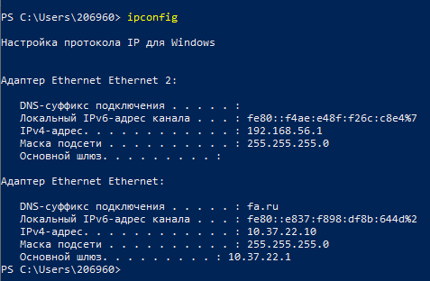

так как у Ethernet 2 нет основного шлюза и DNS суффикса подключения - можно предположить что Ethernet 2 - не активен

# Проверка доступа к сетевому шлюзу

можно попытаться проверить достучавшись до основного шлюза командой, в нашем случае, ping 10.37.22.1

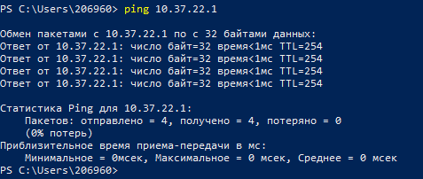

# Проверка доступа к интернету

Доступ к интернету можно проверить командой, например, ping www.dzen.ru

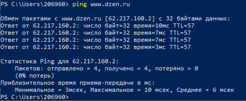

Требуеися поставить

[figure not shown]

Включая отключая его можно проверить доступность сайта из того или иного региона

[figure not shown]

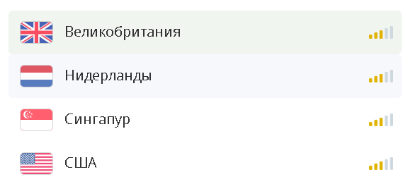

Требуется в отчете предоставить таблицу для ping теста из 4 стран некоторых сайтов. Сайты для проверки

https://www.youtube.com/

https://stackoverflow.com/questions/5898011/jquery-javascript-filtering-html-object-from-ajax-response

https://ru.pinterest.com/

https://www.twitch.tv/terablade

https://w4.cuevana3.ai/

https://kip.eljur.ru/journal-messages-action

http://translit-online.ru/

https://dev.1c-bitrix.ru/community/webdev/user/16002/blog/479/

https://www.youtube.com/watch?v=ZECkSAuy6sg&ab_channel=ТелеканалЮ

https://cloud.mail.ru/public/QaCU/7uQUyPrGD

https://ananasprint.ru/spm/#/

https://mail.rambler.ru/

https://www.mozilla.org/ru/firefox/

https://www.yahoo.com/

https://github.com/IvanSibirevV2/KipFin_Lab_2023_v0_Git0/blob/main/Уп_02_3ПКС_120_220/

https://rutube.ru/video/9eec837c57f774773da9afb1aad1cf93/

# Определение пути IP-пакета.

Кстати, вроде как определяет IP4 сайта...

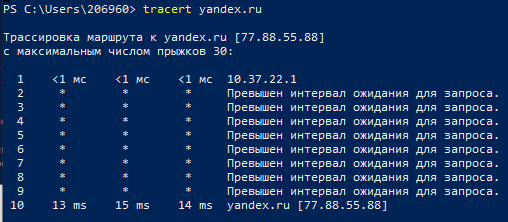

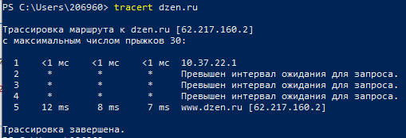

Требуется определить пути пакетов до сайта и отчитаться об этом

Ответить на вопрос...

До какого сайта наибольшее/наименьшее время пинга и наибольшее/наименьшее колличество узлов .

# netstat

Выводит перечень сетевых соединений и прослушиваемых портов локального узла

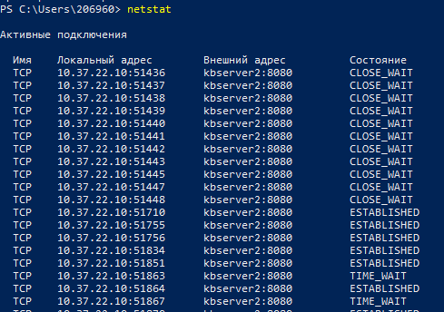

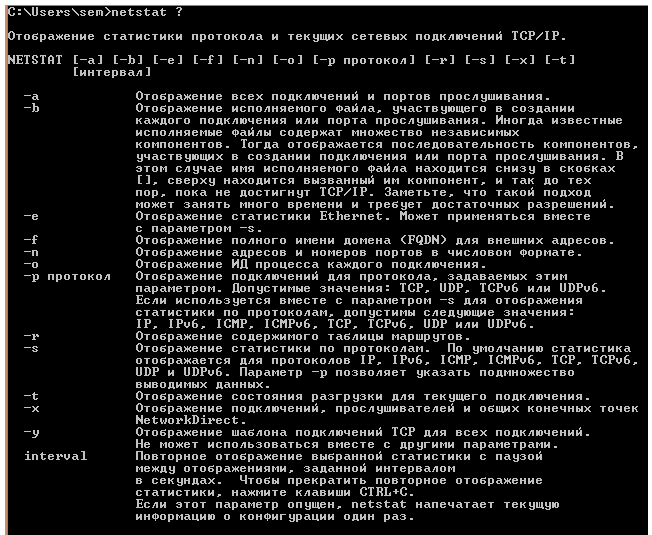

# Получить список маршрутов

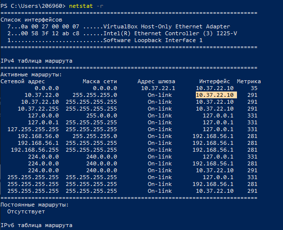

https://topuch.com/uchebnoj-praktike-dlya-studentov/index6.html

Требуется

Получите список активных TCP-соединений локального компьютера.

Получите список активных TCP-соединений локального компьютера без преобразования IP-адресов в символьные имена DNS.

Получите список прослушиваемых компьютером портов TCP и UDP с и без преобразования IP-адресов в символьные имена DNS.

# route

Сетевой адрес – это IP-адрес, адрес сети, или адрес 0.0.0.0 используемый для шлюза по умолчанию Маска сети (Netmask) - маска сети. Для каждого айпи адреса соответствует своя стандартная маска. Адрес шлюза (Gateway) - IP-адрес шлюза, через который будет выполняться отправка пакета для достижения конечной точки. Интерфейс (Interface) - IP-адрес сетевого интерфейса, через который выполняется доставка пакета конечной точке маршрута. Метрика (Metric) - значение метрики (1-9999). Метрика представляет собой числовое значение, позволяющее оптимизировать доставку пакета получателю, если конечная точка маршрута может быть достижима по нескольким разным маршрутам. Чем меньше значение метрики, тем выше приоритет маршрута.

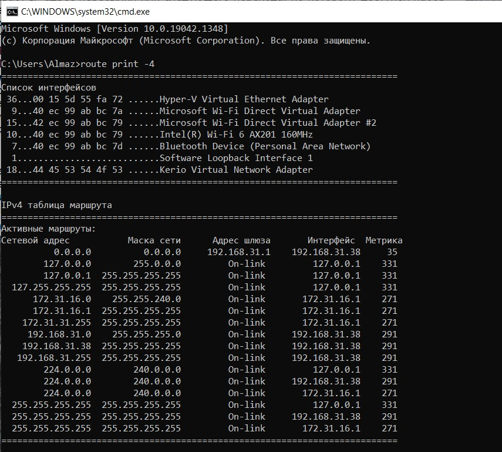

https://cmd4win.ru/administrirovanie-seti/diagnostika-sety/54-route

Требуется получить таблицу маршрутизации для данного компьютера

http://topuch.com/prakticheskaya-rabota-4-marshrutizaciya-paketov-v-ip-setyah/index.html

# Таблица трансляций ip/mac адресов

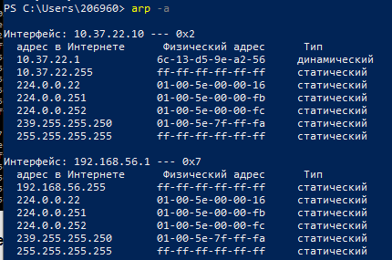

https://windowscomp.ru/nastroika-softa/dlya-chego-nuzhna-komanda-dlya-komandnoj-stroki-arp.html

перейдите на сайт, посмотрите видео ролик

проверить команды на своем компьютере

Написать отчет

[figure not shown]

https://cmd4win.ru/administrirovanie-seti/diagnostika-sety